# Assessing the Health Impact of Air Quality

Yundan Yang, Charles Zhang

[Link to our GitHub webpage](https://jJokerjokes.github.io)

## **Project Goal**

The goal of this project is to analyze air quality data from various regions and investigate its impact on public health, specifically focusing on respiratory diseases. Our primary objective is to correlate pollution levels with public health outcomes, such as hospital admissions and mortality rates. By using datasets like EPA Air Quality Data and the World Air Quality Index, we aim to forecast pollution trends, study the effects of pollutants on specific demographics (e.g., age groups), and visualize pollution levels geographically.

## **Collaboration Plan**

We are committed to working closely together on this project. Given that we live closely, we have the flexibility to meet in person at any time to discuss and advance our project.And we will be using Google Colab for collaborative coding and analysis, ensuring that both of us can contribute and make updates to the project efficiently.

## Table 1

This dataset, sourced from the U.S. Environmental Protection Agency (EPA), provides detailed air quality information collected from monitoring stations across the United States for the year 2024. The dataset captures the concentration levels of various pollutants, including PM2.5 and ozone, measured hourly or over extended periods, depending on the pollutant. Each monitoring site is specified by its geographical location, along with associated metadata such as percentile readings, sampling duration, and local site details.

We chose this dataset for its relevance to studying the impacts of air pollution on public health. It enables us to explore correlations between pollution levels and health outcomes, such as respiratory illnesses or hospital admissions. The data's high resolution across time and location makes it ideal for identifying trends, analyzing seasonal variations in air quality, and evaluating the effectiveness of environmental policies.

```python
import pandas as pd
import numpy as np
import matplotlib.pyplot as plt
import seaborn as sns
from google.colab import drive
drive.mount('/content/drive')

df = pd.read_csv('../annual_conc_by_monitor_2024.csv')
df = df.drop_duplicates()
pd.set_option('display.max_columns', None)
df.head(5)
```

|  | State Code | County Code | Site Num | Parameter Code | POC | Latitude | Longitude | Datum | Parameter Name | Sample Duration | Pollutant Standard | Metric Used | Method Name | Year | Units of Measure | Event Type | Observation Count | Observation Percent | Completeness Indicator | Valid Day Count | Required Day Count | Exceptional Data Count | Null Data Count | Primary Exceedance Count | Secondary Exceedance Count | Certification Indicator | Num Obs Below MDL | Arithmetic Mean | Arithmetic Standard Dev | … |
| --- | --- | --- | --- | --- | --- | --- | --- | --- | --- | --- | --- | --- | --- | --- | --- | --- | --- | --- | --- | --- | --- | --- | --- | --- | --- | --- | --- | --- | --- | --- |
| 0 | 1 | 3 | 10 | 44201 | 1 | 30.497478 | -87.880258 | NAD83 | Ozone | 1 HOUR | Ozone 1-hour 1979 | Daily maxima of observed hourly values (betwee... | INSTRUMENTAL - ULTRA VIOLET ABSORPTION | 2024 | Parts per million | No Events | 708 | 13 | N | 31 | 245 | 0 | 36 | 0.0 | 0.0 | Certification not required | 0 | 0.048871 | 0.010236 | … |
| 1 | 1 | 3 | 10 | 44201 | 1 | 30.497478 | -87.880258 | NAD83 | Ozone | 8-HR RUN AVG BEGIN HOUR | Ozone 8-Hour 1997 | Daily maximum of 8 hour running average of obs... | NaN | 2024 | Parts per million | No Events | 734 | 13 | N | 31 | 245 | 0 | 0 | 0.0 | 0.0 | Certification not required | 0 | 0.039613 | 0.009014 | … |
| 2 | 1 | 3 | 10 | 44201 | 1 | 30.497478 | -87.880258 | NAD83 | Ozone | 8-HR RUN AVG BEGIN HOUR | Ozone 8-Hour 2008 | Daily maximum of 8 hour running average of obs... | NaN | 2024 | Parts per million | No Events | 734 | 13 | N | 31 | 245 | 0 | 0 | 0.0 | 0.0 | Certification not required | 0 | 0.039613 | 0.009014 | … |
| 3 | 1 | 3 | 10 | 44201 | 1 | 30.497478 | -87.880258 | NAD83 | Ozone | 8-HR RUN AVG BEGIN HOUR | Ozone 8-hour 2015 | Daily maximum of 8-hour running average | NaN | 2024 | Parts per million | No Events | 520 | 12 | N | 30 | 245 | 0 | 0 | 0.0 | 0.0 | Certification not required | 0 | 0.039233 | 0.009224 | … |
| 4 | 1 | 3 | 10 | 88101 | 3 | 30.497478 | -87.880258 | NAD83 | PM2.5 - Local Conditions | 1 HOUR | NaN | Observed Values | Met One BAM-1022 Mass Monitor w/ VSCC or TE-PM... | 2024 | Micrograms/cubic meter (LC) | No Events | 2613 | 30 | N | 112 | 366 | 0 | 116 | NaN | NaN | Certification not required | 0 | 5.612361 | 6.704508 | … |

While the original dataframe has numerous variables, we selected the most relavent and useful ones for clarity and sake of analysis.

```python
columns_for_pollution_type = ['Parameter Name', 'Parameter Code', 'Sample Duration',
                   'State Name', 'County Name', 'City Name',
                   'Local Site Name', 'Address', 'Date of Last Change']

df_pollution_type = df[columns_for_pollution_type]
df_pollution_type.head(5)
```

|  | Parameter Name | Parameter Code | Sample Duration | State Name | County Name | City Name | Local Site Name | Address | Date of Last Change |
| --- | --- | --- | --- | --- | --- | --- | --- | --- | --- |
| 0 | Ozone | 44201 | 1 HOUR | Alabama | Baldwin | Fairhope | FAIRHOPE, Alabama | FAIRHOPE HIGH SCHOOL, 1 PIRATE DRIVE, FAIRHOPE... | 2024-07-19 |
| 1 | Ozone | 44201 | 8-HR RUN AVG BEGIN HOUR | Alabama | Baldwin | Fairhope | FAIRHOPE, Alabama | FAIRHOPE HIGH SCHOOL, 1 PIRATE DRIVE, FAIRHOPE... | 2024-07-19 |
| 2 | Ozone | 44201 | 8-HR RUN AVG BEGIN HOUR | Alabama | Baldwin | Fairhope | FAIRHOPE, Alabama | FAIRHOPE HIGH SCHOOL, 1 PIRATE DRIVE, FAIRHOPE... | 2024-07-19 |
| 3 | Ozone | 44201 | 8-HR RUN AVG BEGIN HOUR | Alabama | Baldwin | Fairhope | FAIRHOPE, Alabama | FAIRHOPE HIGH SCHOOL, 1 PIRATE DRIVE, FAIRHOPE... | 2024-07-19 |
| 4 | PM2.5 - Local Conditions | 88101 | 1 HOUR | Alabama | Baldwin | Fairhope | FAIRHOPE, Alabama | FAIRHOPE HIGH SCHOOL, 1 PIRATE DRIVE, FAIRHOPE... | 2024-08-05 |

In this analysis, we decided to focus on the top 15 most frequent parameters from the Parameter Name column.First reason is that the Parameter Name column contains a wide variety of parameter types, making it impractical to visualize all of them at once. Displaying the full range of parameters would clutter the visualization and make it difficult to interpret the results.

By narrowing down to the top 15, we ensure that the graph remains readable and allows us to focus on the most commonly measured pollutants. Also, selecting the most frequent parameters gives us insight into which types of pollution are more commonly monitored and, by extension, which pollutants are more prevalent in the dataset. This focus on the most frequent parameters helps highlight the dominant types of pollution, such as PM2.5 and ozone, providing a clearer picture of the air quality trends in the region.

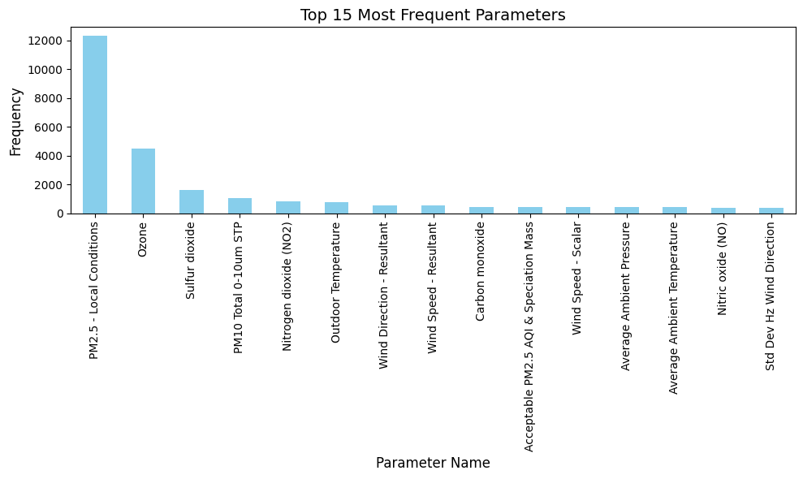

```python
top_15_parameters = df_pollution_type['Parameter Name'].value_counts().nlargest(15)
plt.figure(figsize=(10, 6))
top_15_parameters.plot(kind='bar', color='skyblue')
plt.title('Top 15 Most Frequent Parameters', fontsize=14)
plt.xlabel('Parameter Name', fontsize=12)
plt.ylabel('Frequency', fontsize=12)
plt.xticks(rotation=90)
plt.tight_layout()
```

```python
!jupyter nbconvert --to html your_notebook_name.ipynb
```

[output not shown]